# 5. 함수

### 함수 - function

- 함수는 하나의 관련 작업을 수행하는 데 사용되는 재사용 가능한 코드 블록이다.
  - 함수는 응용 프로그램의 모듈성을 높이고 코드 재사용 수준을 높인다.
- Python은 기본적으로 많은 내장 함수를 제공한다.
- 문자열 등을 다루면서 함수를 사용한 경험을 상기해 보자.
  - `len("Python programming")`
- 필요에 따라 함수를 생성하여 원하는 기능을 따로 분리하여 사용하는 법을 익혀보자.
  - Python에서 제공하는 함수 뿐만 아니라 사용자 정의의 새로운 함수를 만드는 법.
  - Decomposition and abstraction

### 함수 정의의 규칙

- 함수 블록은 키워드 `def`와 함수 이름 및 괄호`()`로 시작한다.
- 모든 입력 매개 변수는 괄호 안에 있어야 한다. 이 괄호 안에 매개 변수를 정의할 수도 있다.
- 모든 함수 내의 코드 블록은 콜론(`:`)으로 시작되고 들여쓰기를 하여야 한다.
- `return [expression]` 명령문은 함수를 종료하고 호출자에게 결과를 전달한다.

```
def function_name(< argument >):
   < something to do >
```

### 함수 예제

- 제곱 후 1을 더해서 반환하는 함수

```python
def square_plus_one(x):
    ans = x ** 2 + 1
    return ans
```

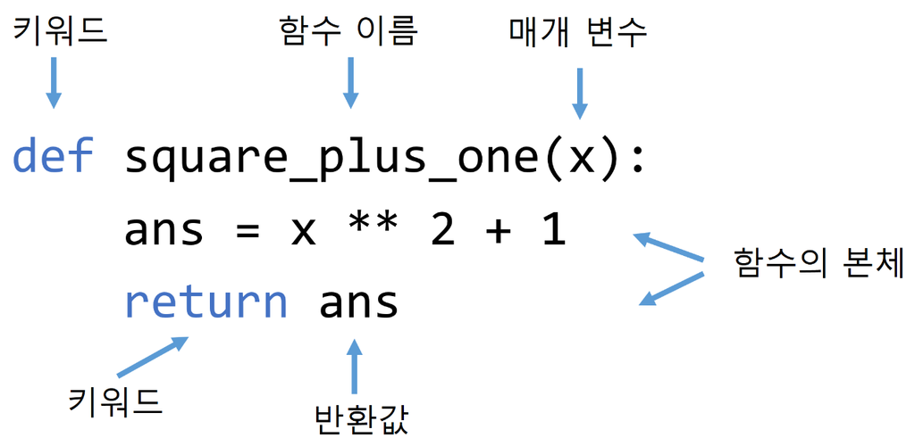

- 함수는 인자(argument)를 입력 받아 `x`라는 매개 변수(parameter)에 대입
- `x**2 + 1` 의 계산을 수행한 후
- 결과를 `ans`에 대입하여 반환(return)하고 있음
- 함수의 정의가 완료되었으면 이 함수를 이용하여 계산을 할 수 있다.
  - `square_plus_one(10)` 등을 수행해 보자.
  - 10이라는 인자를 입력 받아 `x`라는 매개 변수에 대입하여 계산을 수행한 후 결과를 전달한다.

```python
square_plus_one(10)
```

```
101
```

### 함수 예제(2)

- 제곱근 반환 함수

```python
def my_sqrt(x):
    ans = 0
    increment = 1
    while increment >= 0.0001:
        ans += increment
        if ans**2 == x:
            break
        elif ans**2>x:
            ans -= increment
            increment = increment/10.0
    return ans
```

### 함수 사용

- 함수를 정의하였으면 이를 활용할 수 있음

```python
print(my_sqrt(2))
```

```
1.4142
```

```python
y = 16
print(my_sqrt(y))
```

```
4
```

```python
z = 12
print(my_sqrt(z*12))
```

```
12
```

```python
x = my_sqrt(100)
print(x*x)
```

```
100
```

### `return`과 `print`

- 함수를 처음 접하는 경우 `return`과 `print`의 개념을 혼동하는 경우가 많다.
- 이는 Jupyter notebook 등에서 함수를 실행할 때, return 값을 자동으로 화면에 출력하도록 하기 때문이다.
- 실제로는 둘은 전혀 다른 개념이므로 절대로 혼동하지 않도록 한다.
- `return`의 궁극적인 목적은 함수의 계산 결과를 반환하여 이차적으로 활용할 수 있도록 하는 것이고,
- `print`는 단순히 화면에 출력하여 프로그래머가 눈으로 값을 확인할 수 있게 한다.
  - 함수 내에서 사용되는 `print`는 함수 본체 중의 일부일 뿐이다.
- 다음 두 함수를 비교해 보자.

```python
def this_func_print(x):
    print(x ** 2 + 1)

def this_func_return(x):
    return x ** 2 + 1
```

단순히 함수를 실행시켰을 경우, Jupyter notebook이나 콘솔에서의 실행 결과는 비슷해 보인다.

```python
this_func_print(2)
```

```
5
```

```python
this_func_return(2)
```

```
5
```

하지만, `this_func_return`의 결과는 다른 변수에 할당하여, 이차적으로 활용할 수 있는 반면, `this_func_print`는 그렇지 않다.

```python
y = this_func_return(2) # this_func_return(2)의 결과 5가 y에 대입된다.
print(y / 10)           # y를 다른 계산에 활용할 수 있다. 5/10 = 0.5
```

```
0.5
```

`this_func_print`의 `return`은 존재하지 않으며, python에서는 이를 `None`이라는 값으로 처리한다.  
따라서 다음 코드에서 `y`의 값은 `None`에 불과하며 이를 이차적으로 활용할 방안은 많지 않다.

```python
y = this_func_print(2)   # this_func_print(2) 결과는 5로 정상 출력되지만
print(y)                 # y는 None으로 큰 의미가 없음, 즉 다른 계산에 활용할 수 없다.
```

```
5
None
```

### 인자가 없는 경우

- 함수는 아무런 인자를 받지 않을 수 있음
- 빈 괄호 ()로 표현된다.

```python
def print_something():
    print("This function does nothing.")
```

- 위 함수는 아무런 인자를 받지 않을 뿐만 아니라, 아무런 반환값도 없음 (`None`을 반환)
  - `return`을 찾을 수 없다.
  - `print_something()` 함수를 실행해 보자.

```python
print_something()
```

```
This function does nothing.
```

- 인자가 필요하지만 함수 호출 시 입력하지 않았을 경우 에러가 발생한다.

```python
def printme(stri):
    print("Input is :", stri)
    return

printme()
```

```
---------------------------------------------------------------------------
TypeError                                 Traceback (most recent call last)
<ipython-input-15-46fdeebb8fc1> in <module>
      3     return
      4
----> 5 printme()

TypeError: printme() missing 1 required positional argument: 'stri'
```

- 다음과 같이 인자가 어떤 값을 입력받는지 확실히 표현할 수도 있다.
  - `(stri = "My string")`이라고 표현한 것에 주목하자.

```python
def printme(stri):
    print("Input is :", stri)
    return


printme(stri = "My string")
```

```
Input is : My string
```

### 여러 개의 인자를 받는 함수

- 함수는 여러 개의 인자를 받을 수 있다.

```python
def printinfo(name, age):
    print("Name: ", name)
    print("Age: ", age)
    return

printinfo(age=50, name="miki")
```

```
Name:  miki
Age:  50
```

```python
def my_max(x, y):
    if x >= y:
          return x
    else:
          return y
```

```python
my_max(10,12)
```

```
12
```

### 여러 개의 인자를 받는 함수(2)

- 최대공약수를 구하는 함수

```python
def my_GCD(x, y):
    j = 1
    ans = 1
    while j <= x and j <= y:
        if x%j == 0 and y%j == 0:
            ans = j
        j += 1
    return ans
```

```python
my_GCD(24, 84)
```

```
12
```

- 최소공배수를 구하는 함수도 만들어 보자.

### 예제

```python
def printName(firstName, lastName, reverse):
    if reverse:
          print(lastName + ', ' + firstName)
    else:
          print(firstName, lastName)
```

- 다음은 동치

```python
printName('Kyungsub', 'Lee', False)
printName('Kyungsub', 'Lee', reverse=False)
printName(lastName='Lee', firstName='Kyungsub', reverse=False)
```

```
Kyungsub Lee
Kyungsub Lee
Kyungsub Lee
```

### default parameter

- 함수 생성 시 다음과 같이 default parameter를 설정할 수 있다.
- default parameter는 입력값이 따로 없을 때, 미리 설정된 default값을 이용한다.

```python
def printName(firstName, lastName, reverse = False):
    if reverse:
         print(lastName + ', ' + firstName)
    else:
         print(firstName, lastName)

printName('Kyungsub', 'Lee')
```

```
Kyungsub Lee
```

```python
printName('Kyungsub', 'Lee', True)
```

```
Lee, Kyungsub
```

```python
def printinfo( name, age = 35 ):
    print("Name: ", name)
    print("Age: ", age)
    return
```

```python
printinfo( age=50, name="miki" )
printinfo( name="miki" )
```

```
Name:  miki
Age:  50
Name:  miki
Age:  35
```

### 지역 변수(local variable)

- 함수 내의 변수는 함수 내에서만 존재하는 변수

```python
def my_func():
    x = 20

x = 10
my_func()
print(x)
```

```
10
```

- 함수 내의 지역 변수와 함수 바깥의 전역 변수(global variable)이 분리되어 있음을 주의

```python
def my_func():
    x = 20
    return x

x = 10
x = my_func()
print(x)
```

```
20
```

```python
def increase(x):
    x = x + 1

x=1
increase(x)
print(x)
```

```
1
```

```python
def increase(x):
    x = x + 1
    return x

x = 1
x = increase(x)
print(x)
```

```
2
```

#### 변수 scope 더 살펴보기

변수의 scope는 해당 변수가 파이썬 인터프리터에게 보이거나 액세스 가능한 범위를 나타낸다.

다음의 예제에서 변수 `x`는 함수 내에 존재하지 않기 때문에, 함수 바깥에서 정의된 `x`의 값을 가져온다.

```python
x = 1
def print_x():
    print(x)

print_x()
```

```
1
```

다음은 함수 밖에 `x`가 정의되어 있어 있지만, 함수 내에서 `x`가 다시 정의되다.  
이 경우 함수 내에서 `x`를 사용할 때는, 함수 내에서 정의된 `x`가 우선 순위를 가진다.

```python
x = 1
def print_x():
    x = 2
    print(x)

print_x()
```

```
2
```

### 농장 문제

- 농장에 돼지들과 닭들이 있다. 총 머리의 수는 20개, 총 다리의 수는 56개이다. 돼지와 닭의 수는 각각 얼마인가?
  - Brute force 방법으로 풀어보자.

```python
for x in range(0,21):
    y = 20 - x
    if 4*x + 2*y == 56:
         break
print(x, y)
```

```
8 12
```

### 농장 문제 – 함수

- 임의의 머리 수와 다리 수가 주어졌을 때, 돼지와 닭의 수를 구하는 함수를 작성해 보자.

```python
def farm(numHeads, numLegs):
    for x in range(0, numHeads + 1):
        y = numHeads - x
        if 4*x + 2*y == numLegs:
              return x, y
```

```python
print(farm(20, 56))
```

```
(8, 12)
```

```python
print(farm(20, 60))
```

```
(10, 10)
```

### None

- Python에서 없는 값을 나타내기 위해 사용되는 값
- None을 이용하여 해가 없는 경우를 대비하여 보자.

```python
def farm(numHeads, numLegs):
    for x in range(0, numHeads + 1):
        y = numHeads - x
        if 4*x + 2*y == numLegs:
            return x, y
    return None, None

farm(100,10)
```

```
(None, None)
```

### 함수를 호출하는 함수

```python
def farm_UI():
    heads = int(input('Enter the number of heads : '))
    legs = int(input('Enther the number of legs : '))
    pigs, chickens = farm(heads, legs)
    if pigs == None:
        print('No solution')
    else:
        print('Number of pigs : ', pigs)
        print('Number of chickens : ', chickens)

farm_UI()
```

```
Enter the number of heads : 30
Enther the number of legs : 90
Number of pigs :  15
Number of chickens :  15
```

### Built-in function

- Python에 이미 내장되어 있는 built-in function들을 활용할 수 있음
- https://docs.python.org/3/library/functions.html
- `range()`, `str()`, `raw()`, `len()`, …
- `max()`, `min()`, `abs()`, `type()`, …

### `lambda`

`lambda`는 비교적 간단한 함수를 생성할 때 사용하는 키워드로 `def`와 비슷한 역할을 한다.

- `lambda arguments: expression`

```python
def my_add_plus_one1(x, y): return x + y + 1
```

위 함수 정의는 다음의 방법으로 거의 똑같이 구현할 수 있다.

- `lambda`와 `:` 사이에 parameter들이 오며, `:`뒤에 return값을 배치한다.

```python
my_add_plus_one2 = lambda x, y: x + y + 1
```

```python
my_add_plus_one2(1, 2)
```

```
4
```

`lambda` 방법의 장점은 함수에 특별히 이름을 붙이지 않아도 함수를 사용가능 하도록 한다는 점이다.

- 이를 anonymous function이라고도 부른다.

```python
(lambda x, y: x + y + 1)(1, 2)
```

```
4
```

### Module

- 기본적으로 제공하는 Built-in function 외에도 module을 통하여 다양한 함수 제공
- 예
  - math 모듈
    - 기본적인 수학 연산을 도와주는 모듈
    - https://docs.python.org/3/library/math.html
  - random 모듈
    - 다양한 분포에 대한 random number를 활용할 수 있게 해주는 모듈
    - https://docs.python.org/3/library/random.html
- import 명령을 사용하여 모듈을 불러와 사용

### Math module

- `import math`
- `math.sqrt(x)`
  - x의 제곱근 반환
- `math.exp(x)`
  - e**x 반환
- `math.sin(x)`
  - sin 함수값 반환
- `math.pi`
  - 3.141592…

```python
import math
math.sqrt(71)
```

```
8.426149773176359
```

```python
math.sin(math.pi / 2)
```

```
1.0
```

```python
math.log(4) / math.log(2)
```

```
2.0
```

```python
math.log(4) % math.log(2)
```

```
0.0
```

```python
math.log(8) / math.log(2)
```

```
3.0
```

```python
# 실수 간의 나머지를 계산할 때는 주의하여야 한다.
math.log(8) % math.log(2)
```

```
0.6931471805599452
```

### division - 나누기

- 다음은 Python 3.x에서는 해당되지 않는 내용이다.
- Python 2.x에서는 나누기(`/`)를 사용시 기본적으로 정수를 먼저 반환하려고 함.
  - `5/2 = 2`
- Python 2.x에서 실수 나누기를 하고 싶은 경우
  - `5/2.0` 혹은 `5/float(2)`
- 만약 Python 2.x에서 default로 실수를 반환하는 나누기(`/`)를 사용하고 싶을 때, 다음 `import`문을 사용할 수 있음
  - `from __future__ import division`
- 이 노트북은 Python 3를 기반으로 작성되었지만, Jupyter cell magic 중의 하나인 `%%python2`를 이용하면 Python 2를 시험해 볼 수 있다.
  - Python 2가 설치되어 있지 않은 컴퓨터에서는 작동하지 않는다.

```python
%%python2

print(5/2)
```

```
2
```

```python
%%python2

print(5/2.0)
```

```
2.5
```

```python
%%python2

from __future__ import division
print(5/2)
```

```
2.5
```

```python
%%python2

print(5//2)
```

```
2
```

### Random module

- `import random`
- `random.random()`
  - 0이상 1이하의 랜덤값 반환
- `random.uniform(a,b)`
  - a이상 b이하에서 uniform 분포를 가지는 랜덤값 반환
- `random.randint(a,b)`
  - a이상 b이하의 랜덤 정수 반환
- `random.gauss(mu, sigma)`, `random.normalvariate(mu, sigma)`
  - 평균 mu, 표준편차 sigma의 정규 분포를 가지는 랜덤값 반환

```python
import random
random.random()
```

```
0.6355622417507467
```

```python
random.uniform(0, 10)
```

```
7.871653464850869
```

```python
random.randint(1, 5)
```

```
1
```

```python
random.gauss(0, 1)
```

```
1.205317944980681
```

#### 예제 : 랜덤 숫자를 맞추는 프로그램

1부터 100까지의 숫자를 랜덤으로 생성 후 키보드 입력을 통해 그 숫자를 맞추는 프로그램

```python
import random
def guess():
    a = random.randint(1, 100)
    while(True):
        x = input("Guess the number between 1 to 100 (type q to quit) : ")

        if x == "q":
            return
        elif a == int(x):
            print("Correct!")
            return
        elif a < int(x):
            print("The number is smaller than your guess, try again.")
        elif a > int(x):
            print("The number is larger than your guess, try again.")
        else:
            print("Please input appropriate number.")
```

```python
guess()
```

```
Guess the number between 1 to 100 (type q to quit) : 50
The number is smaller than your guess, try again.
Guess the number between 1 to 100 (type q to quit) : 25
The number is smaller than your guess, try again.
Guess the number between 1 to 100 (type q to quit) : 12
The number is larger than your guess, try again.
Guess the number between 1 to 100 (type q to quit) : 18
The number is larger than your guess, try again.
Guess the number between 1 to 100 (type q to quit) : 21
The number is smaller than your guess, try again.
Guess the number between 1 to 100 (type q to quit) : 20
Correct!
```

### t – 랜덤 변수

- gauss() 함수와 gammavariate() 함수를 이용하여 t-분포를 따르는 랜덤 변수를 생성하는 함수

```python
import math
import random

def student_t(nu): # nu equals number of degrees of freedom
    x = random.gauss(0.0, 1.0)
    y = 2.0*random.gammavariate(0.5*nu, 2.0)
    return x / (math.sqrt(y/nu))
```

```python
student_t(10)
```

```
-0.044457342435589894
```

#### 모듈 파일을 불러오는 다양한 방법

```python
import random
random.randint(1, 10)
```

```
9
```

```python
from random import *
randint(1, 10)
```

```
4
```

```python
import random as r
r.randint(1, 10)
```

```
10
```

### 모듈에 대한 여러 가지

- 파이썬 스크립트 파일로 모듈을 만들 수 있음
  - 기본 작업 directory에 저장하여 import 할 수 있음
  - `import fibo`
- 모듈 변경과 갱신
  - 혹시 모듈을 변경하였다면 `reload` 명령을 이용하여 갱신
    - `from imp import reload`
    - `reload(fibo)`

```python
import fibo
fibo.fib(50)
```

```
1, 1, 2, 3, 5, 8, 13, 21, 34,
```